# Seguimiento del número de fallecimientos diarios en el Perú

Datos del Sistema Informático Nacional de Defunciones, SINADEF

Raúl Eyzaguirre

19/06/2020

## 1. Introducción

### Problemas con los datos

Las provincias de Chiclayo, Ferreñafe y Lambayeque presentan una disminución considerable en el número de fallecidos con respecto al 2017. En la siguiente tabla se ve el número total de fallecidos en estas tres provincias en los años 2017, 2018 y 2019.

| Provincia | Total fallecidos 2017 | Total fallecidos 2018 | Total fallecidos 2019 |
| --- | --- | --- | --- |
| Chiclayo | 4171 | 2896 | 438 |
| Ferreñafe | 469 | 294 | 51 |
| Lambayeque | 1335 | 879 | 130 |

## 2. Número total de fallecimientos por año

Los siguientes gráficos permiten evaluar el efecto COVID-19; el primero en el sentido más amplio pues incluye, entre otros factores:

- El incremento en el número de fallecimientos debido a COVID-19.
- El incremento en el número de fallecimientos debido a otras enfermedades que quedan desatendidas en el contexto actual.
- La disminución en el número de fallecimientos por causas violentas como los accidentes de tránsito.

El segundo gráfico no considera el posible efecto positivo en la disminución del número de muertes violentas.

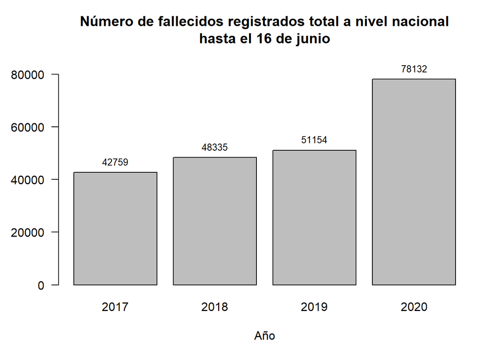

La diferencia a la fecha entre este año y el 2019 es de 26978 para el número total de fallecidos.

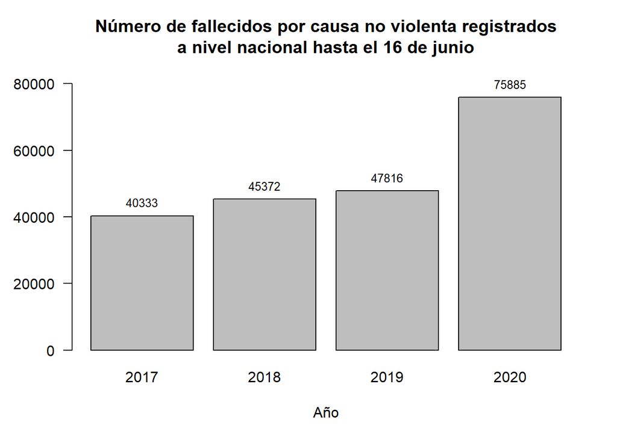

La diferencia a la fecha entre este año y el 2019 es de 28069 para el número de fallecidos por causa no violenta.

## 3. Evolución del número de fallecidos diarios por causa no violenta en el 2020

Los siguientes gráficos permiten evaluar la evolución de la epidemia a través de su efecto en el número de fallecimientos diarios por causa no violenta, a nivel nacional y en las provincias con mayor población.

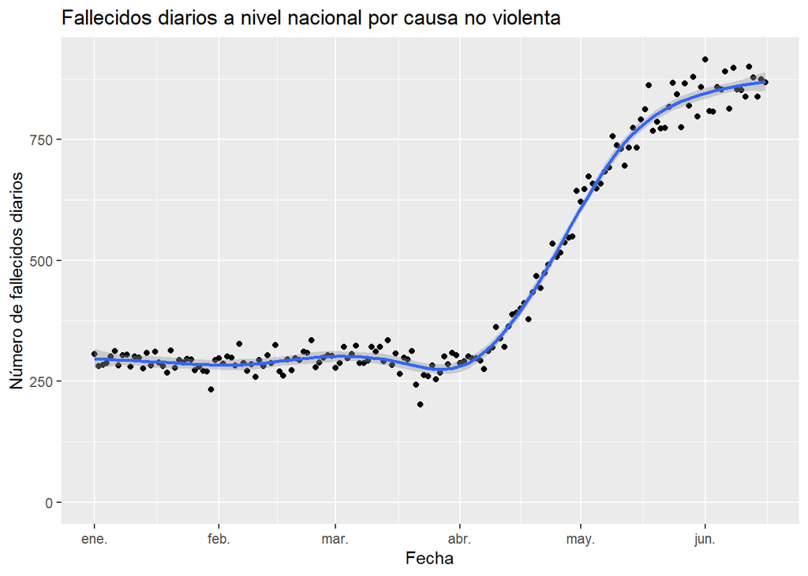

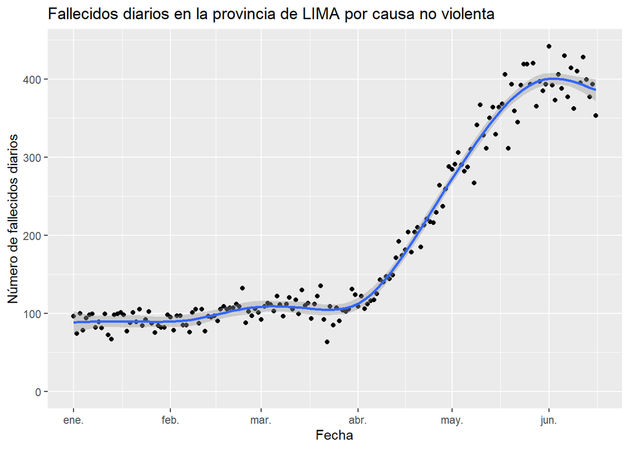

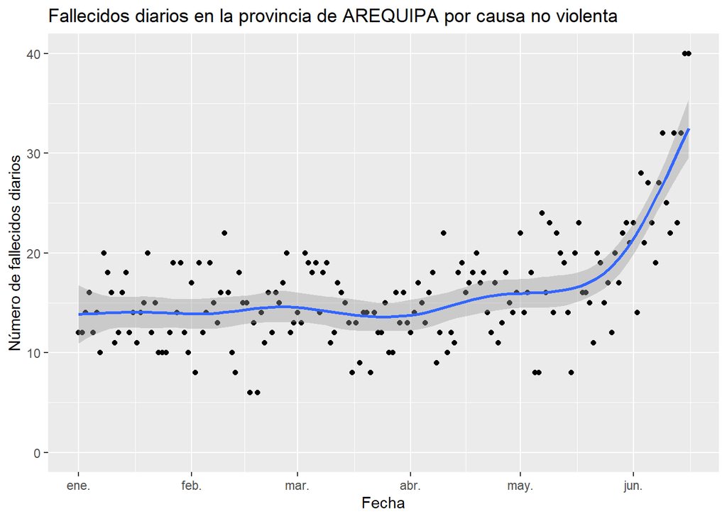

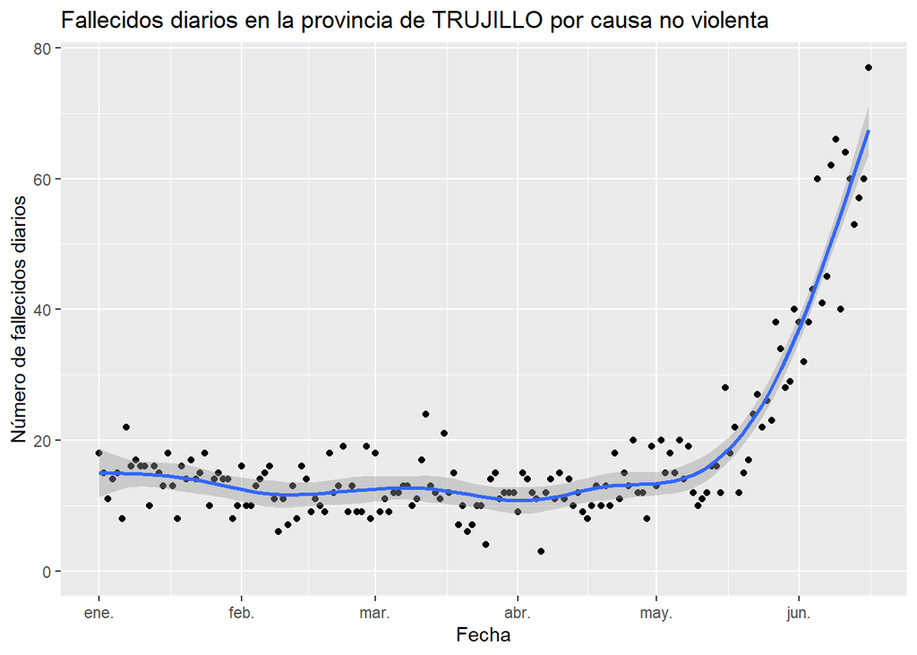

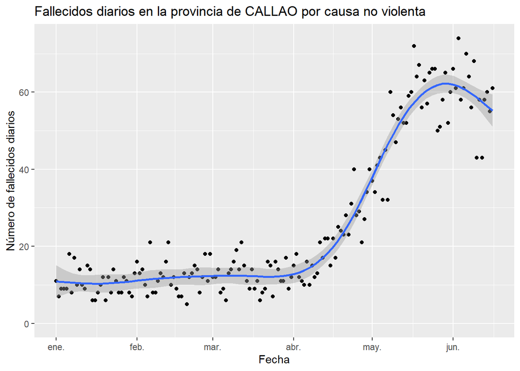

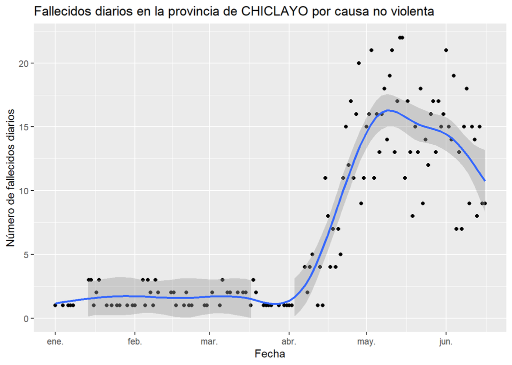

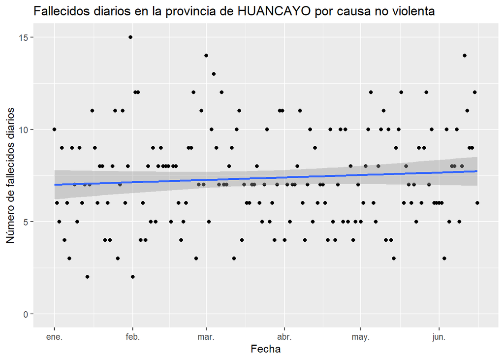

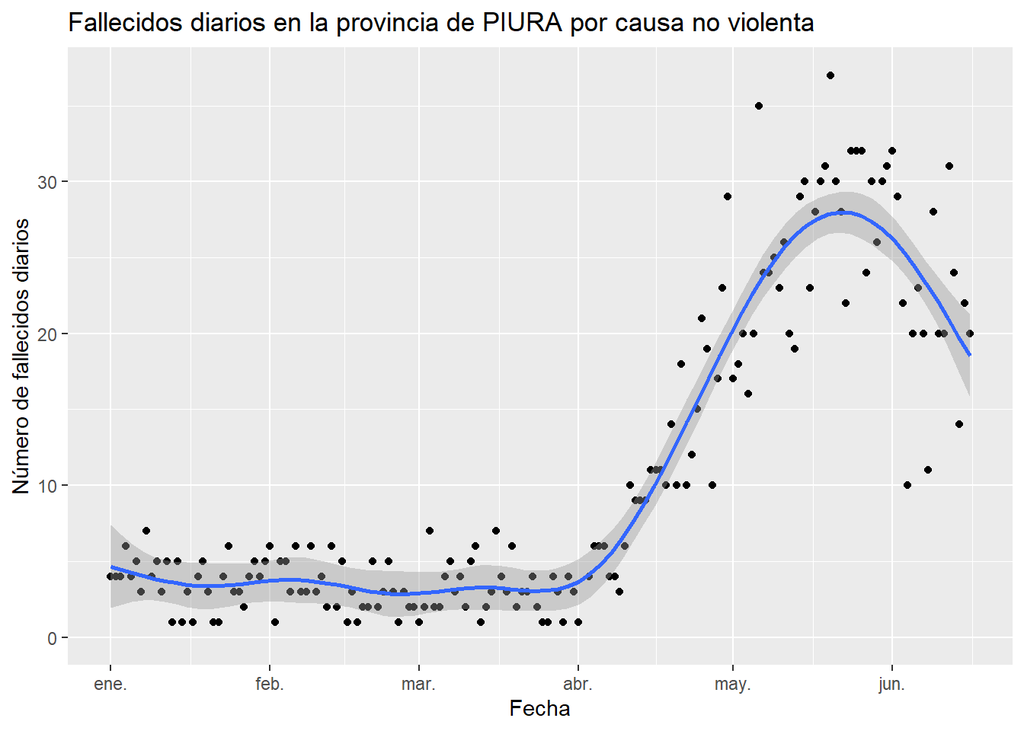

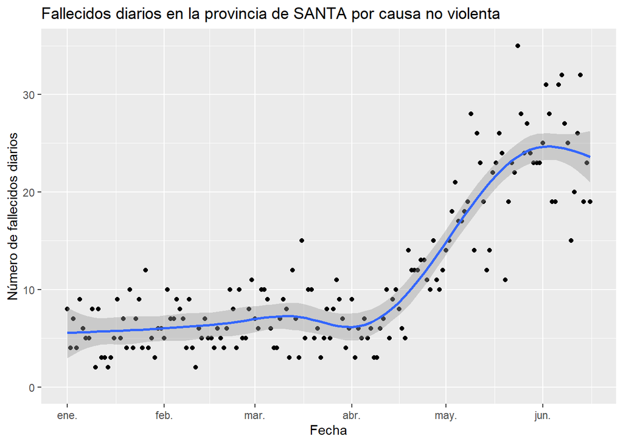

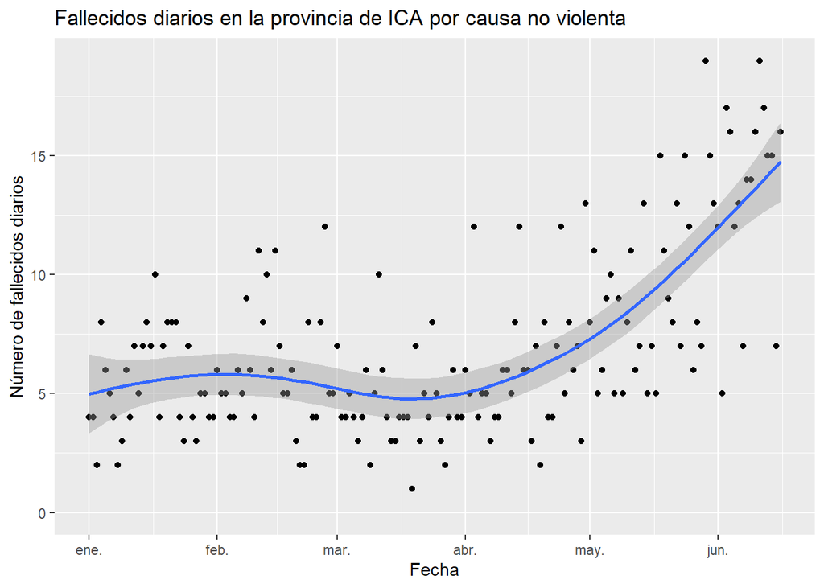

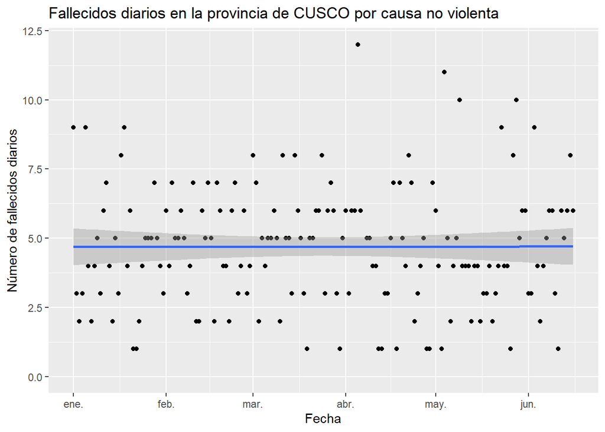

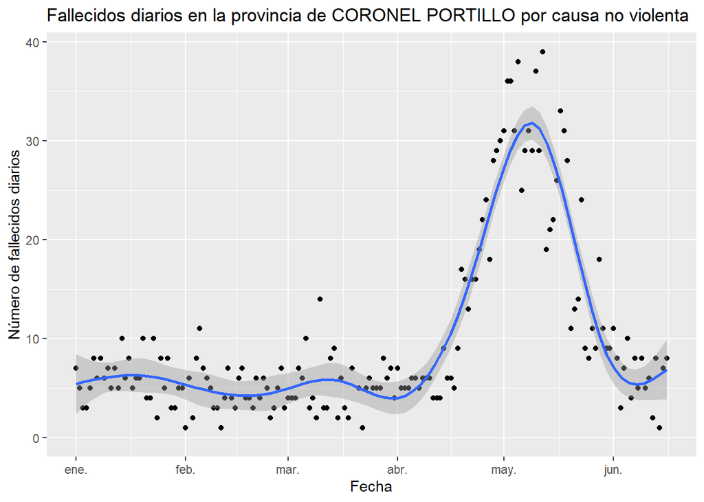

[10 more figures not shown]

## 4. Provincias y distritos con mayor incremento de fallecidos por causa no violenta en el último mes

En los siguientes gráficos se observan las 20 provincias y 40 distritos con mayor incremento de fallecimientos por causa no violenta en el último mes con respecto a la media del mismo periodo en el 2018 y 2019. Estos gráficos permiten identificar las provincias y distritos en los que la enfermedad podría haber avanzado más. Para evitar el efecto de muestras pequeñas, solo se consideran las provincias y distritos con un promedio de fallecimientos mensual mayor a 10 en la media del 2018 y 2019.

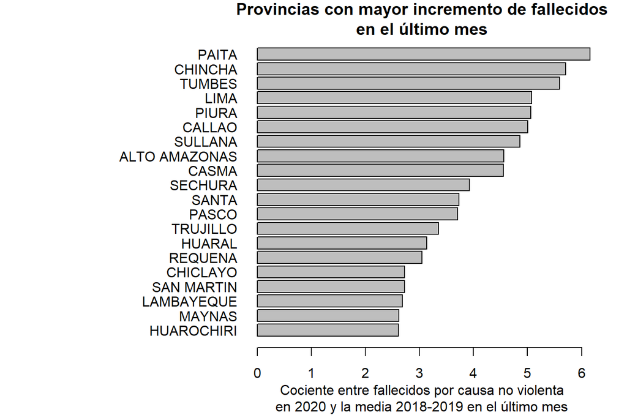

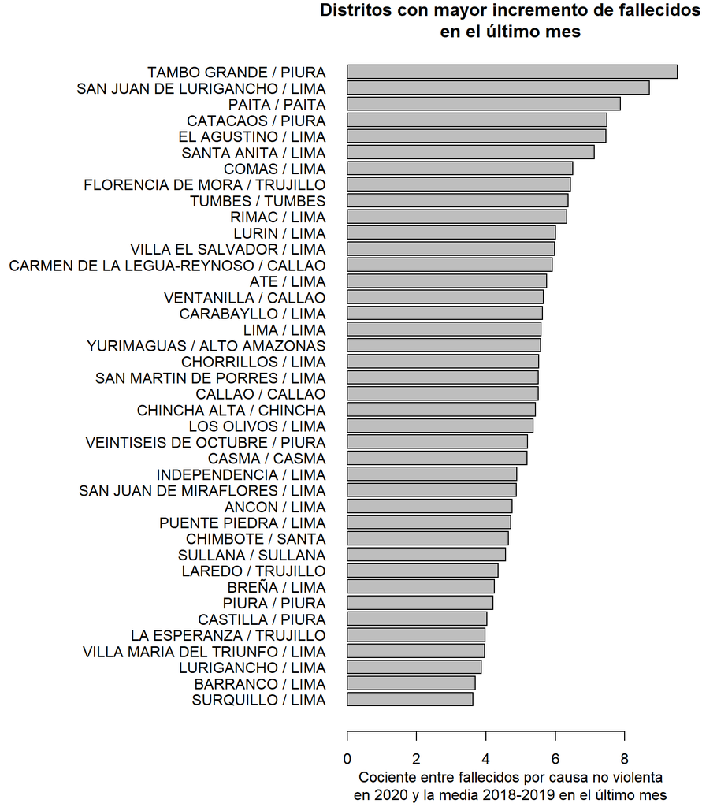

## 5. Exceso de fallecidos con respecto a la media de los años 2018 y 2019 por cada 1000 habitantes

Si evaluamos el exceso de fallecidos este año con respecto a la media de los años 2018 y 2019 y lo presentamos como número de fallecidos por mil habitantes, podemos tener un indicador del avance de la enfermedad en el país y por provincia. En los gráficos de la sección 3 se puede identificar a ciertas provincias que ya habrían pasado por el pico para el número de fallecidos diarios, luego, el valor para el número de fallecidos por mil habitantes para estas provincias podría servir como un referente en relación con el pico de la enfermedad.

En la siguiente tabla se muestra el exceso de fallecidos en el 2020 con respecto a la media del 2018 y 2019 expresado en proporción por cada mil para algunas provincias y para el total nacional. Para la población total en todos los casos se toma como referencia la población registrada en [censo del 2017](https://es.wikipedia.org/wiki/Anexo:Provincias_del_Perú).

| Provincia | Exceso de fallecidos por 1000 habitantes |
| --- | --- |
| Chincha | 2.6668 |
| Callao | 2.4847 |
| Coronel Portillo | 2.3714 |
| Lima | 2.2789 |
| Tumbes | 2.2554 |
| Santa | 2.1684 |
| Casma | 1.9122 |
| Maynas | 1.8786 |
| Huarochiri | 1.5823 |
| Paita | 1.5513 |
| Piura | 1.1335 |
| Sullana | 1.1318 |
| Trujillo | 1.1124 |
| Alto Amazonas | 1.0389 |
| Total nacional | 0.8986 |

## 6. Efecto COVID-19 y altura

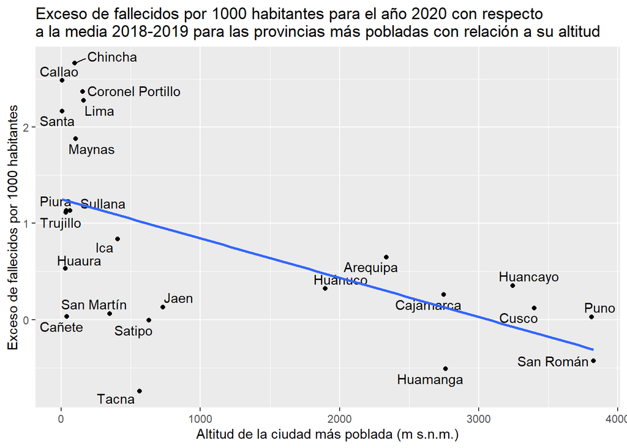

## 7. Evolución del número de fallecidos diarios por causa no violenta en el 2020 por edad y sexo

Se sabe que la letalidad de COVID-19 es mayor en hombres que en mujeres y que se incrementa considerablemente con la edad. Los siguientes gráficos permiten evaluar el efecto de la epidemia por sexo y edad en el Perú.

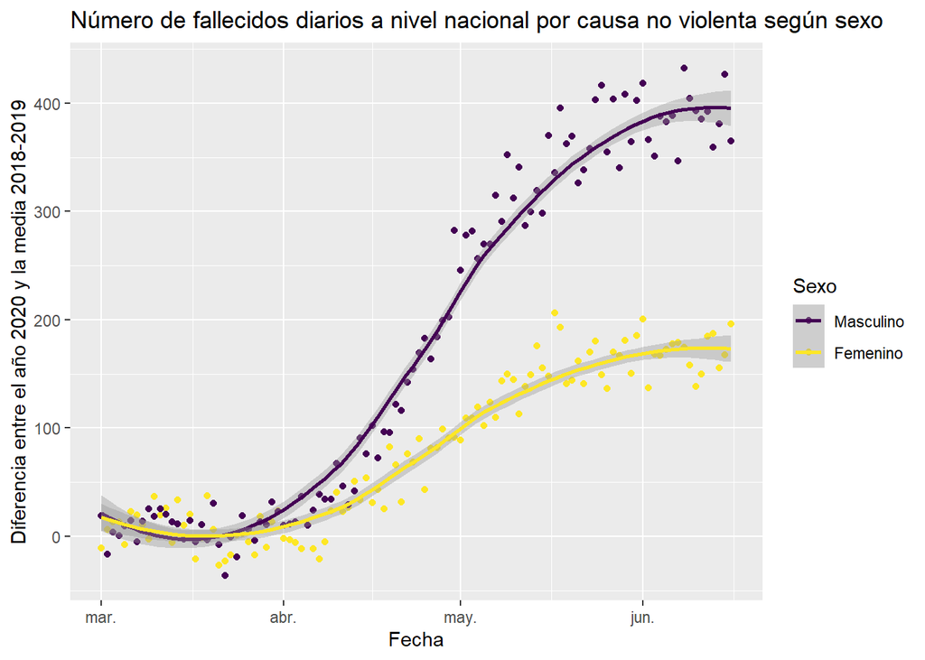

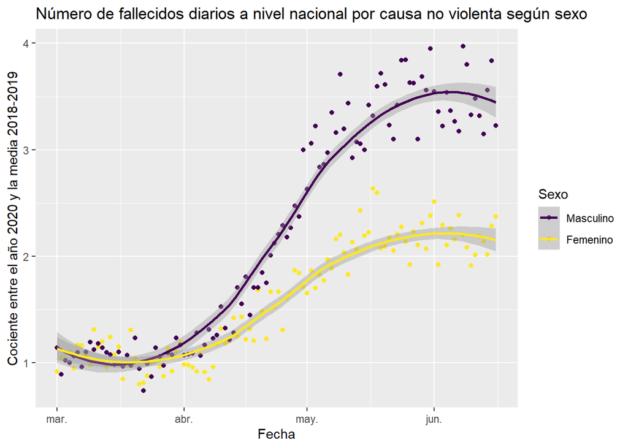

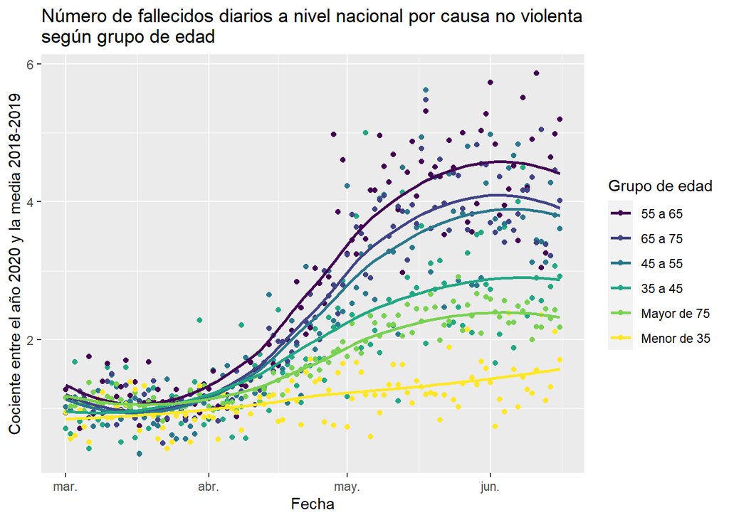